# Análise de regressão logística

Author

Alda Botelho Azevedo

Published

February 3, 2025

# 1 Criar o dataset

```r
set.seed(456)
n <- 200

# Gerando os preditores:
sqft <- round(runif(n, 800, 3500))
bedrooms <- sample(1:6, n, replace = TRUE)
age <- round(runif(n, 0, 100))
has_pool <- rbinom(n, 1, 0.2)

# Simulando um modelo logístico para o atributo "luxo".
# Definimos um preditor linear (lp) combinando os preditores.
lp <- -10 + 0.005 * sqft + 0.8 * bedrooms - 0.05 * age + 1.5 * has_pool

# Converte o preditor linear em probabilidade usando a função logística
p_luxury <- exp(lp) / (1 + exp(lp))

# Gera a variável de resposta: se a casa for de luxo (luxury = 1, "Sim") ou não (luxury = 0, "Não")
luxury_binary <- rbinom(n, 1, p_luxury)
luxury <- factor(ifelse(luxury_binary == 1, "Sim", "Não"))

# Cria o data frame
dados_habitacao <- data.frame(
  sqft = sqft,
  bedrooms = bedrooms,
  age = age,
  has_pool = factor(has_pool, levels = c(0, 1), labels = c("Não", "Sim")),
  luxury = luxury
)
```

# 2 Inspeciona o conjunto de dados

```r
str(dados_habitacao)
```

```
'data.frame':   200 obs. of  5 variables:
 $ sqft    : num  1042 1368 2779 3101 2929 ...
 $ bedrooms: int  2 1 6 5 5 6 5 3 3 3 ...
 $ age     : num  25 3 81 21 53 41 43 0 74 27 ...
 $ has_pool: Factor w/ 2 levels "Não","Sim": 1 1 2 1 1 2 2 1 1 1 ...
 $ luxury  : Factor w/ 2 levels "Não","Sim": 1 1 2 2 2 2 1 2 1 2 ...
```

```r
table(dados_habitacao$luxury)
```

```
Não Sim
 74 126
```

# 3 Ajusta o modelo de regressão logística utilizando todos os preditores

```r
modelo_logistico <- glm(luxury ~ sqft + bedrooms + age + has_pool,
                        data = dados_habitacao, family = binomial)
summary(modelo_logistico)
```

```
Call:
glm(formula = luxury ~ sqft + bedrooms + age + has_pool, family = binomial,
    data = dados_habitacao)

Deviance Residuals:
     Min        1Q    Median        3Q       Max
-2.54296  -0.15040   0.02387   0.22001   2.21514

Coefficients:
              Estimate Std. Error z value Pr(>|z|)
(Intercept) -9.8795255  1.7912245  -5.516 3.48e-08 ***
sqft         0.0056239  0.0009262   6.072 1.26e-09 ***
bedrooms     0.6376171  0.1927342   3.308 0.000939 ***
age         -0.0617423  0.0142182  -4.342 1.41e-05 ***
has_poolSim  1.0659173  0.7342935   1.452 0.146606
---
Signif. codes:  0 '***' 0.001 '**' 0.01 '*' 0.05 '.' 0.1 ' ' 1

(Dispersion parameter for binomial family taken to be 1)

    Null deviance: 263.582  on 199  degrees of freedom
Residual deviance:  81.773  on 195  degrees of freedom
AIC: 91.773

Number of Fisher Scoring iterations: 7
```

**Como interpreto o output?**

Intercepto (-9.88): Representa o log-odds* em valores que variam de -∞ a +∞, facilitando o ajuste do modelo) de uma habitação sem quartos, sem área, idade zero e sem piscina ser considerado de luxo (um cenário meramente teórico).

*escala natural dos coeficientes na regressão logística, transforma probabilidades (que variam entre 0 e 1)

Área (sqft = 0.0056): Por cada unidade de imcremento de 1 sqft na casa, aumenta o log-odds de ser luxo em 0.0056.Imóveis maiores têm maior probabilidade de serem de luxo.

Número de quartos (bedrooms = 0.6376): Cada quarto adicional aumenta os log-odds em 0.6376, tornando o imóvel mais propenso a ser de luxo.

Idade (age = -0.0617): Cada ano adicional reduz os log-odds de ser luxo em 0.0617. Ou seja, imóveis mais antigos são menos propensos a serem de luxo.

Piscina (has_poolSim = 1.0659): Não é estatisticamente significativo (p = 0.1466 > 0.05).

Desempenho do Modelo

Null deviance: 263.582 (df = 199) - Mede o erro do modelo sem preditores (apenas com a média da variável resposta). Residual deviance: 81.773 (df = 195) - Mede o erro do modelo com preditores. Quanto menor, melhor o ajuste. (Importante para comparar com modelos com outras variáveis)

AIC: 91.773 - Critério de informação de Akaike: menor AIC indica melhor ajuste.(Importante para comparar com modelos com outras variáveis)

Número de iterações de Fisher Scoring: 7 - Indica o número de iterações até a convergência do modelo.(Quantos menos, melhor.)

Interpretação Geral

O modelo ajusta bem os dados, pois a deviance caiu de 263 para 81. sqft, bedrooms e age são preditores estatisticamente significativos do status de luxo das casas. Ter piscina não tem um efeito estatisticamente significativo nesta classificação.

Podemos interpretar os coeficientes como variações nos log-odds, mas para facilitar a compreensão, podemos convertê-los em razões de chances (odds ratios) com exp(coef(modelo)). Let’s do it :)

# 4 Calcular as razões de chances (odds ratios) e os intervalos de confiança de 95%

```r
exp_coef <- exp(coef(modelo_logistico))
exp_ci <- exp(confint(modelo_logistico))
odds_ratios <- data.frame(Estimativa = exp_coef, `2.5 %` = exp_ci[, 1], `97.5 %` = exp_ci[, 2])
print(odds_ratios)
```

```
              Estimativa       X2.5..      X97.5..
(Intercept) 5.121257e-05 8.786094e-07  0.001112326
sqft        1.005640e+00 1.004062e+00  1.007766212
bedrooms    1.891967e+00 1.329169e+00  2.857523849
age         9.401251e-01 9.111525e-01  0.964023980
has_poolSim 2.903501e+00 7.332941e-01 13.483937494
```

**Como Interpreto o output?** Intercepto (≈0.000051): Representa os odds quando todas as variáveis preditoras são zero.Sem variáveis preditoras, a chance do imóvel ser de luxo é praticamente nula. sqft (1.0056): Cada aumento de 1 unidade na área do imóvel aumenta os odds de ser de luxo em 0.56%, efeito pequeno. Cada quarto adicional multiplica os odds por 1.89. Significa que casas com mais quartos têm quase o dobro de chances de serem de luxo. Cada ano a mais na idade do imóvel reduz os odds em 5.99% (1 - 0.9401 = 0.0599). Casas mais antigas têm menor probabilidade de serem classificadas como de luxo.

(se o intervalo de confiança não inclui 1, o efeito é significativo)

# 5 Previsões

```r
# Prever a probabilidade de luxo para cada observação
dados_habitacao$prob_prevista <- predict(modelo_logistico, type = "response")
```

# 6 Classificar as casas como “Sim” (luxo) se a probabilidade prevista for maior que 0.5, caso contrário “Não”

```r
dados_habitacao$luxo_previsto <- ifelse(dados_habitacao$prob_prevista > 0.5, "Sim", "Não")
print(dados_habitacao$luxo_previsto)
```

```
  [1] "Não" "Não" "Sim" "Sim" "Sim" "Sim" "Não" "Sim" "Não" "Sim" "Sim" "Não"
 [13] "Sim" "Sim" "Não" "Sim" "Sim" "Não" "Sim" "Não" "Não" "Sim" "Sim" "Sim"
 [25] "Sim" "Sim" "Sim" "Sim" "Não" "Não" "Sim" "Não" "Sim" "Sim" "Sim" "Sim"
 [37] "Sim" "Sim" "Sim" "Sim" "Não" "Não" "Não" "Não" "Não" "Não" "Sim" "Sim"
 [49] "Sim" "Sim" "Sim" "Sim" "Sim" "Sim" "Sim" "Sim" "Sim" "Sim" "Não" "Não"
 [61] "Sim" "Não" "Não" "Sim" "Não" "Sim" "Sim" "Não" "Sim" "Sim" "Sim" "Sim"
 [73] "Não" "Não" "Não" "Não" "Não" "Não" "Sim" "Sim" "Não" "Não" "Sim" "Sim"
 [85] "Não" "Sim" "Não" "Não" "Sim" "Sim" "Sim" "Sim" "Sim" "Sim" "Sim" "Sim"
 [97] "Não" "Não" "Sim" "Sim" "Não" "Não" "Não" "Não" "Sim" "Sim" "Sim" "Sim"
[109] "Sim" "Não" "Sim" "Sim" "Sim" "Sim" "Sim" "Sim" "Sim" "Sim" "Sim" "Sim"
[121] "Não" "Não" "Não" "Sim" "Não" "Sim" "Sim" "Sim" "Sim" "Não" "Sim" "Sim"
[133] "Sim" "Sim" "Não" "Sim" "Não" "Sim" "Não" "Sim" "Sim" "Não" "Sim" "Não"
[145] "Não" "Sim" "Sim" "Sim" "Sim" "Sim" "Sim" "Sim" "Sim" "Não" "Não" "Sim"
[157] "Não" "Sim" "Sim" "Sim" "Não" "Sim" "Sim" "Sim" "Sim" "Não" "Sim" "Não"
[169] "Sim" "Sim" "Sim" "Sim" "Não" "Não" "Sim" "Sim" "Não" "Sim" "Não" "Sim"
[181] "Não" "Sim" "Não" "Não" "Sim" "Sim" "Sim" "Sim" "Não" "Não" "Sim" "Não"
[193] "Sim" "Não" "Sim" "Não" "Sim" "Sim" "Não" "Não"
```

# 7 Matriz de confusão: comparar as classificações reais com as previstas

```r
matriz_confusao <- table(Real = dados_habitacao$luxury, Previsto = dados_habitacao$luxo_previsto)
print(matriz_confusao)
```

```
     Previsto
Real  Não Sim
  Não  64  10
  Sim   9 117
```

Curva ROC para Avaliação do Modelo

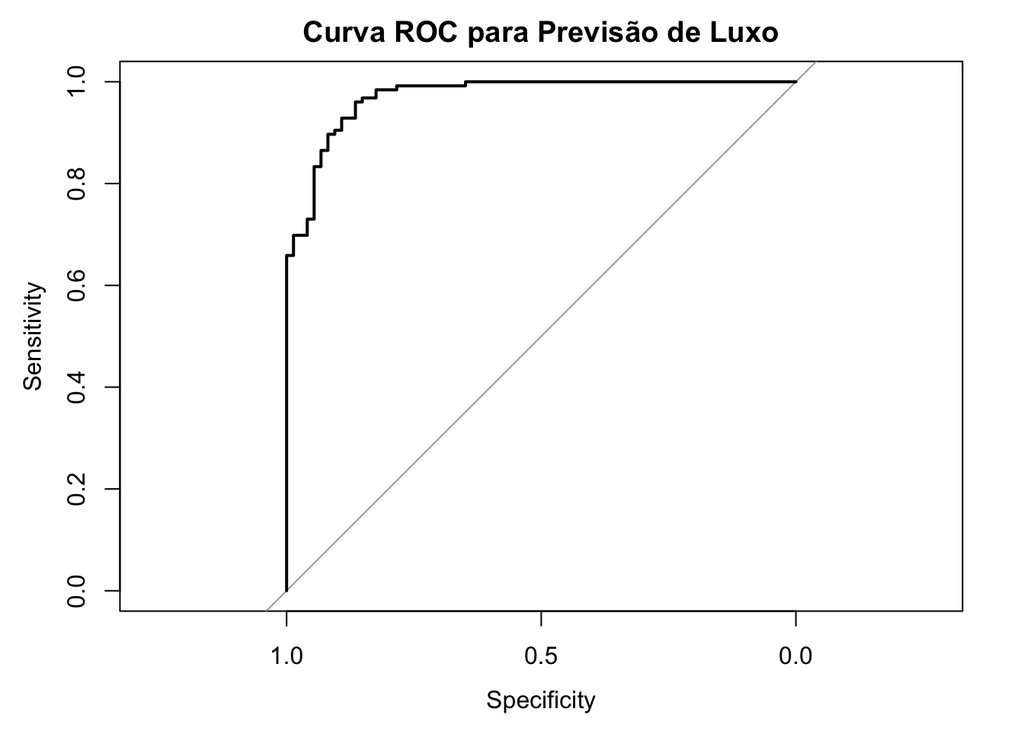

```r
library(pROC)
roc_obj <- roc(dados_habitacao$luxury, dados_habitacao$prob_prevista, levels = c("Não", "Sim"))
plot(roc_obj, main = "Curva ROC para Previsão de Luxo")
```

```r
auc_value <- auc(roc_obj)
print(auc_value)
```

```
Area under the curve: 0.9718
```